# 14.Example 3

Modified

Mo 2026-09-21 21:41

## Given:

Consider an air heater consisting of a semicircular tube for which the plane surface is maintained at $1000\ \mathrm{K}$ and the other surface is well insulated. The tube radius is $20\ \mathrm{mm}$, and both surfaces have an emissivity of $0.8$.

## Required:

If atmospheric air flows through the tube at $0.01\ \frac{\mathrm{kg}}{\mathrm{s}}$ and $T_m = 400\ \mathrm{K}$, what is the temperature of the insulated surface?

## Solution:

Start first by defining all of the given values.

$$T_1 = 1000\ \mathrm{K}$$
$$r_o = 20\ \mathrm{mm}$$
$$\varepsilon = 0.8$$
$$\dot{m} = 0.01\ \frac{\mathrm{kg}}{\mathrm{s}}$$
$$T_m = 400\ \mathrm{K}$$

Other known quantities that will be used are shown below.

$$\sigma = 5.67\times 10^{-8}\ \frac{\mathrm{W}}{\left(\mathrm{K}^{4} \cdot \mathrm{m}^{2}\right)}$$

A sketch of the system is shown below.

Figure 1: System Sketch

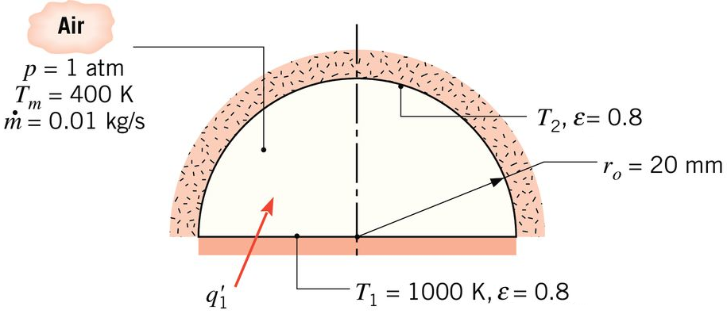

The equivalent radiation circuit is shown below.

Figure 2: Thermal Circuit

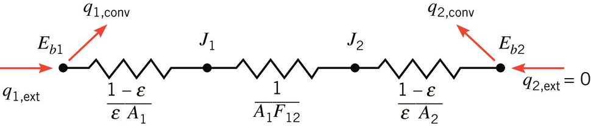

Beginning with a 1st Law look of the surface of the semicircular portion yields

$$\frac{dE_{sys}}{dt} = \Sigma E_{in} - \Sigma E_{out}$$

$$\frac{dE_{sys}}{dt} = - q_{2,rad} - q_{2,conv}$$

For steady state conditions, the surface energy balance becomes

$$0 = - q_{2,rad} - q_{2,conv}$$

Thus,

$$- q_{2,rad} = q_{2,conv}$$

or

$$\frac{\sigma \left(T_1^4 - T_2^4 \right)}{R_{tot}^\prime} = h A_2^\prime \left(T_2 - T_m \right)$$

The surface areas per unit length are given by

$$A_1^\prime = 2 r_o = 40\ \mathrm{mm}$$

$$A_2^\prime = \pi r_o = 62.83\ \mathrm{mm}$$

The view factor for this arrangement is

$$F_{12} = 1$$

The equivalent resistance is then

$$R_{tot}^\prime = \frac{1 - \varepsilon}{\varepsilon A_1^\prime} + \frac{1}{A_1^\prime F_{12}} + \frac{1 - \varepsilon}{\varepsilon A_2^\prime} = 0.03523\ \frac{1}{\mathrm{mm}}$$

To find the convective coefficient $h$, the hydraulic diameter must first be found. The hydraulic diameter is given by

$$D_h = \frac{4 A_c}{P}$$

where $A_c$ is the cross-sectional area, and $P$ is the wetted perimeter. The cross-sectional area is given by

$$A_c = \frac{\pi r_o^2}{2} = 628.3\ \mathrm{mm}^{2}$$

The wetted perimeter is given by

$$P = \pi r_o + 2 r_o = 102.8\ \mathrm{mm}$$

The hydraulic diameter is then

$$D_h = \frac{4 A_c}{P} = 24.44\ \mathrm{mm}$$

To calculate the Reynolds, material properties of air must first be found. Going to Table A.4 at $T_m$ shows

$$c_p = 1.014\ \frac{\mathrm{kJ}}{\left(\mathrm{K} \cdot \mathrm{kg}\right)}$$
$$\mu = 2.301\times 10^{-5}\ \frac{\mathrm{N} \cdot \mathrm{s}}{\mathrm{m}^{2}}$$
$$k = 0.0338\ \frac{\mathrm{W}}{\left(\mathrm{K} \cdot \mathrm{m}\right)}$$
$$Pr = 0.69$$

The Reynolds number may now be calculated by

$$Re_D = \frac{\rho u_m D_h}{\mu}$$

Recognizing that mass flow rate is

$$\dot{m} = \rho u_m A_c$$

The Reynolds number expression becomes

$$Re = \frac{\dot{m} D_h}{A_c \mu} = 1.691\times 10^{4}$$

The Reynolds number is significantly high so fully developed turbulent flow will be assumed. Referring to the reference equations for internal flow for various geometries shows that a semicircular cross-section is not one of the listed geometries. In light of this, a circular cross-section will be assumed. Thus, the Nusselt number is given by

$$Nu_D = 0.023 Re_D^{\frac{4}{5}} Pr^{0.4} = 47.83$$

The convective coefficient is then given by

$$h = \frac{k Nu_D}{D_h} = 66.14\ \frac{\mathrm{W}}{\left(\mathrm{K} \cdot \mathrm{m}^{2}\right)}$$

Now that the convective coefficient has been found, the only unknown variable is $T_2$. Unfortunately, $T_2$ may not be found explicitly. An iterative approach must be used to find $T_2$. The first step is to solve the previously found surface energy balance for a single $T_2$. This is shown below.

$$T_2 = \frac{\frac{\sigma \left(T_1^4 - T_2^4 \right)}{R_{tot}^\prime} + h A_2^\prime T_m}{h A_2^\prime}$$

The next step is to make an initial guess for $T_2$. A maximum value that could be expected from $T_2$ is $1000\ \mathrm{K}$. This will be used for the initial guess.

$$T_2 = 1000\ \mathrm{K}$$

Now that a guess has been made, the value of $T_2$ may be calculated. This is shown below.

$$T_2 = \frac{\frac{\sigma (T_1^4 - T_2^4)}{R_{tot}^\prime} + h A_2^\prime T_m}{h A_2^\prime} = 400.0\ \mathrm{K}$$

Since the guess and the calculated value do not equal another interaction must be preformed. This is shown below.

$$T_2 = \frac{\frac{\sigma (T_1^4 - T_2^4)}{R_{tot}^\prime} + h A_2^\prime T_m}{h A_2^\prime} = 777.4\ \mathrm{K}$$

This step must be performed until the guess value and the calculated value are the same. This is shown below.

$$T_2 = \frac{\frac{\sigma (T_1^4 - T_2^4)}{R_{tot}^\prime} + h A_2^\prime T_m}{h A_2^\prime} = 645.9\ \mathrm{K}$$

$$T_2 = \frac{\frac{\sigma (T_1^4 - T_2^4)}{R_{tot}^\prime} + h A_2^\prime T_m}{h A_2^\prime} = 719.9\ \mathrm{K}$$

$$T_2 = \frac{\frac{\sigma (T_1^4 - T_2^4)}{R_{tot}^\prime} + h A_2^\prime T_m}{h A_2^\prime} = 683.3\ \mathrm{K}$$

$$T_2 = \frac{\frac{\sigma (T_1^4 - T_2^4)}{R_{tot}^\prime} + h A_2^\prime T_m}{h A_2^\prime} = 702.9\ \mathrm{K}$$

$$T_2 = \frac{\frac{\sigma (T_1^4 - T_2^4)}{R_{tot}^\prime} + h A_2^\prime T_m}{h A_2^\prime} = 692.8\ \mathrm{K}$$

$$T_2 = \frac{\frac{\sigma (T_1^4 - T_2^4)}{R_{tot}^\prime} + h A_2^\prime T_m}{h A_2^\prime} = 698.1\ \mathrm{K}$$

$$T_2 = \frac{\frac{\sigma (T_1^4 - T_2^4)}{R_{tot}^\prime} + h A_2^\prime T_m}{h A_2^\prime} = 695.3\ \mathrm{K}$$

$$T_2 = \frac{\frac{\sigma (T_1^4 - T_2^4)}{R_{tot}^\prime} + h A_2^\prime T_m}{h A_2^\prime} = 696.8\ \mathrm{K}$$

$$T_2 = \frac{\frac{\sigma (T_1^4 - T_2^4)}{R_{tot}^\prime} + h A_2^\prime T_m}{h A_2^\prime} = 696.0\ \mathrm{K}$$

$$T_2 = \frac{\frac{\sigma (T_1^4 - T_2^4)}{R_{tot}^\prime} + h A_2^\prime T_m}{h A_2^\prime} = 696.4\ \mathrm{K}$$

$$T_2 = \frac{\frac{\sigma (T_1^4 - T_2^4)}{R_{tot}^\prime} + h A_2^\prime T_m}{h A_2^\prime} = 696.2\ \mathrm{K}$$

$$T_2 = \frac{\frac{\sigma (T_1^4 - T_2^4)}{R_{tot}^\prime} + h A_2^\prime T_m}{h A_2^\prime} = 696.3\ \mathrm{K}$$

$$T_2 = \frac{\frac{\sigma (T_1^4 - T_2^4)}{R_{tot}^\prime} + h A_2^\prime T_m}{h A_2^\prime} = 696.2\ \mathrm{K}$$

Since the guess and the calculate value are the same (within one decimal place), a good enough solution has been reached.

Answer: $T_2 = 696.2\ \mathrm{K}$